# Aula 11 - Análise Fatorial - Aula Prática

#Modelo de Análise de Fatores

$$\mathbf{X} - \boldsymbol{\mu} = \mathbf{LF} + \boldsymbol{\epsilon}$$
em que:

- $\mathbf{X}$ é um vetor que representa as variáveis de dimensão $p \times 1$;
- $\mathbf{L}$ é um matriz de *loadings* de dimensões $p \times m$;
- $\mathbf{F}$ é o vetor de variáveis latentes (fatores) de dimensão $m \times 1$;
- $\boldsymbol{\epsilon}$ é um vetor de variâncias específicas de dimensão $p \times 1$.
- $\mathbf{F} \sim (\mathbf{0},\mathbf{I}_m)$, ou seja, fatores latentes com média zero, variância unitária e não correlacionados.
- $\boldsymbol{\epsilon} \sim (\mathbf{0}, \boldsymbol{\Psi})$ em que $\boldsymbol{\Psi} = \mbox{diag}(\psi_1, \ldots, \psi_p)$ com $\psi_j$ denotando a j-ésima variância específica.
- $\epsilon_j$ e $F_k$ são independentes de uma ou otra para os pares $j,k$.

#Modelo de Fatores Ortogonais implica em uma estrutura de covariâncias

$$Var(\mathbf{X}) = \boldsymbol{\Sigma} = \mathbf{L}\mathbf{L}^{'} + \boldsymbol{\Psi}$$

##Covariância entre $\mathbf{X}$ e $\mathbf{F}$

$$Cov(\mathbf{X},\mathbf{F}) = \mathbf{L}.$$

##Variância Explicada pelos Fatores Comuns

$$\sigma_{jj} = h^2_j + \psi_j$$
em que

- $\sigma_{jj}$ é a variância amostral de $X_j$;
- $h^2_j = (\mathbf{LL}^{'})_{jj} = l^2_{j1} + \ldots + l^2_{jm}$ é a comunalidade de $X_j$;
- $\psi_j$ é a variância espcífica (ou unicidade) de $X_j$;

#Modelo de Análise de Fatores

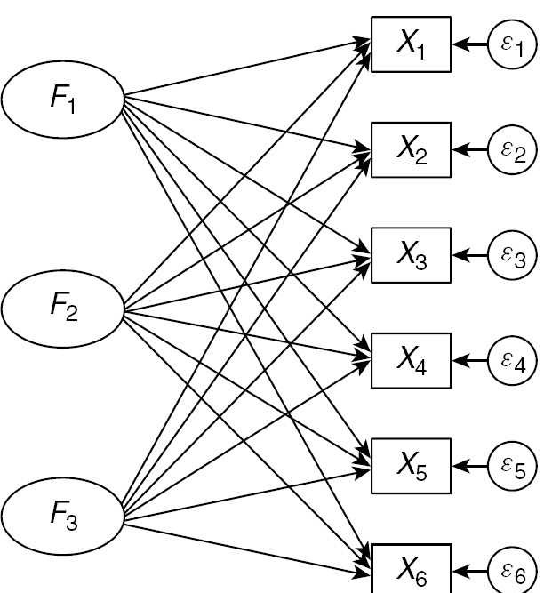

#Exemplo Prático - Decatlon

- Dados usados aqui refere-se a perfomance dos atletas durante dois eventos esportivos (Olimpíadas de 2004 e Decstar 2004)
- Na prática, temos um `data.frame` com 41 linhas e 13 colunas:
- As primeiras 10 colunas correspondem a performance dos atletas para 10 eventos de decatlon.
- As colunas 11, 12 e 13 correspondem respectivamente ao rank, pontos obtidos e o evento esportivo.

##Esportes

- X100m; Long.jump; Shot.put; High.jump; X400m; X110m.hurdle; Discus; Pole.vault; Javeline; X1500m.
- 100 m; Salto `a Distância; Arremesso de peso; Salto em Altura; 400 m; 110 m com barras; Arremesso de discos; Salto com vara; Dardo; 1500 m

#Exemplos Práticos

##Medidas Resumo

```
##       100m         Long.jump       Shot.put       High.jump          400m
##  Min.   :10.44   Min.   :6.61   Min.   :12.68   Min.   :1.850   Min.   :46.81
##  1st Qu.:10.85   1st Qu.:7.03   1st Qu.:13.88   1st Qu.:1.920   1st Qu.:48.93
##  Median :10.98   Median :7.30   Median :14.57   Median :1.950   Median :49.40
##  Mean   :11.00   Mean   :7.26   Mean   :14.48   Mean   :1.977   Mean   :49.62
##  3rd Qu.:11.14   3rd Qu.:7.48   3rd Qu.:14.97   3rd Qu.:2.040   3rd Qu.:50.30
##  Max.   :11.64   Max.   :7.96   Max.   :16.36   Max.   :2.150   Max.   :53.20
##   110m.hurdle        Discus        Pole.vault       Javeline
##  Min.   :13.97   Min.   :37.92   Min.   :4.200   Min.   :50.31
##  1st Qu.:14.21   1st Qu.:41.90   1st Qu.:4.500   1st Qu.:55.27
##  Median :14.48   Median :44.41   Median :4.800   Median :58.36
##  Mean   :14.61   Mean   :44.33   Mean   :4.762   Mean   :58.32
##  3rd Qu.:14.98   3rd Qu.:46.07   3rd Qu.:4.920   3rd Qu.:60.89
##  Max.   :15.67   Max.   :51.65   Max.   :5.400   Max.   :70.52
##      1500m
##  Min.   :262.1
##  1st Qu.:271.0
##  Median :278.1
##  Mean   :279.0
##  3rd Qu.:285.1
##  Max.   :317.0
```

#Interpretação

- Observamos que a escala e a amplitude das variáveis são diferentes;
- Portanto, vamos trabalhar com a matriz de correlação.

#Matriz de Correlação e Distribuição dos Dados

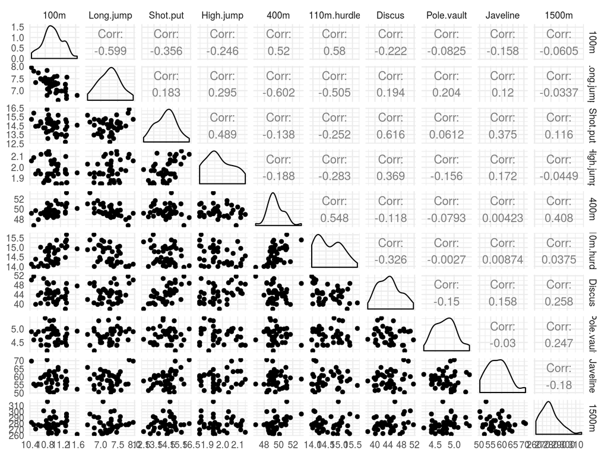

#Determinação de Número de Fatores

- Existem diversos métodos para determinar números de fatores.
- Aqui, vamos analisar:
- Proporção acumulada da variância total devido aos $m$ fatores.
- Escolher $m$ como sendo o menor número cuja a proporção acumulada seja maior ou igual a 70%.

Ou

- Scree plot (Gráfico da Declividade)
- Nesse gráfico busca-se um “cotovelo” ou a partir de número de fatores os autovalores se estabilizam.

Ou

- Escolher $m$ como sendo o maior número cujos os autovalores sejam maiores que 1.

#Proporção acumulada da variância total devido aos $m$ fatores.

```
##                         PC1   PC2   PC3   PC4   PC5   PC6   PC7   PC8   PC9
## SS loadings           3.272 1.737 1.405 1.057 0.685 0.599 0.451 0.397 0.215
## Proportion Var        0.327 0.174 0.140 0.106 0.068 0.060 0.045 0.040 0.021
## Cumulative Var        0.327 0.501 0.641 0.747 0.816 0.875 0.921 0.960 0.982
## Proportion Explained  0.327 0.174 0.140 0.106 0.068 0.060 0.045 0.040 0.021
## Cumulative Proportion 0.327 0.501 0.641 0.747 0.816 0.875 0.921 0.960 0.982
##                        PC10
## SS loadings           0.182
## Proportion Var        0.018
## Cumulative Var        1.000
## Proportion Explained  0.018
## Cumulative Proportion 1.000
```

#Scree plot

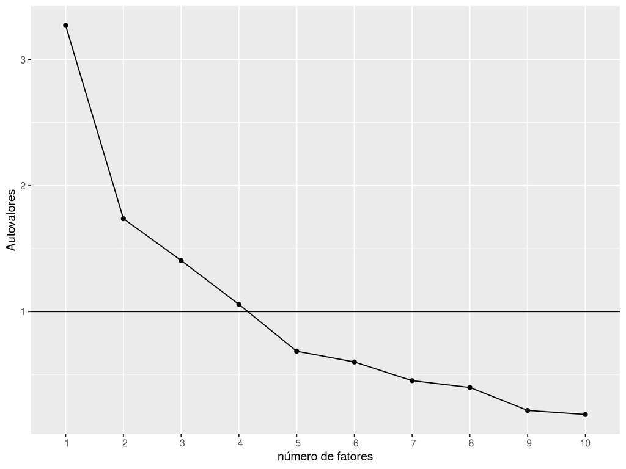

#Interpretação dos Resultados

- Baseado em uma análise conjunta dos 3 critérios vamos utilizar $m = 4$.

#Estimação dos Parâmetros - EMV

```
##
## Call:
## factanal(x = df, factors = 4, scores = "none", rotation = "none")
##
## Uniquenesses:
##        100m   Long.jump    Shot.put   High.jump        400m 110m.hurdle
##       0.409       0.386       0.005       0.680       0.270       0.464
##      Discus  Pole.vault    Javeline       1500m
##       0.492       0.005       0.800       0.005
##
## Loadings:
##             Factor1 Factor2 Factor3 Factor4
## 100m         0.674  -0.293  -0.206
## Long.jump   -0.725   0.101   0.158  -0.231
## Shot.put             0.880   0.448  -0.142
## High.jump   -0.198   0.527
## 400m         0.697  -0.170   0.148   0.440
## 110m.hurdle  0.680  -0.246
## Discus      -0.178   0.592   0.284   0.213
## Pole.vault          -0.387   0.715  -0.577
## Javeline             0.389          -0.199
## 1500m               -0.156   0.764   0.623
##
##                Factor1 Factor2 Factor3 Factor4
## SS loadings      2.010   1.913   1.473   1.089
## Proportion Var   0.201   0.191   0.147   0.109
## Cumulative Var   0.201   0.392   0.540   0.648
##
## Test of the hypothesis that 4 factors are sufficient.
## The chi square statistic is 9.2 on 11 degrees of freedom.
## The p-value is 0.603
```

#Estimativas das Comunalidades

```r
apply(dec.fa$loadings^2,1,sum)
```

```
##        100m   Long.jump    Shot.put   High.jump        400m 110m.hurdle
##   0.5912191   0.6143945   0.9950026   0.3202901   0.7302068   0.5359179
##      Discus  Pole.vault    Javeline       1500m
##   0.5077426   0.9950003   0.1997807   0.9950038
```

##Interpretação

Um modelo de fator apropriado resulta em valores baixos para variâncias específicas e altos valores para comunalidade.

#Interpretação do output

- O primeiro *chunk* provê “the uniquenesses” (variância específica) $\hat{\psi}_i$.
- Corresponde a proporção da variabilidade, o qual não pode ser explicada por uma combinação linear dos fatores.
- Altos valores de $\hat{\psi}_i$ indica que os fatores não quantifica bem essa variância.
- O próximo *chunk* são os loadings. Os “loadings” são as contribuições de cada variável original ao fator.
- **Variáveis com alto valores de loadings** são **bem explicadas por aquele fator**
- Observe que para algumas varáveis o valor do loading não é impresso. Isso porque o R não imprime valores de loadings menores que 0.1. Isso serve para nos ajudar a identificar grupos de variáveis.

#Interpretação do output

- A tabela abaixo dos *loadings* mostra a proporção de variação explicada por cada fator.
- A linha *SS loadings* é a soma de quadrados dos loadings dentro de cada coluna.
- A segunda linha *Proportion Var* é simplesmente *SS loadings* dividido pelo número de linhas da matriz de loadings. Vale a pena manter um fator se *SS loadings* for maior que 1 (regra de Kaiser).
- A terceira linha *Cumulative Var* é a proporção da variância acumulada

#Interpretação do output

- A última seção da saída da função mostra os resultados de um teste de hipótese.
- A hipótese nula, $H_0$, é que o número de fatores no modelo, é suficiente para capturar a dimensionalidade completa do conjunto de dados.
- Se rejeitarmos $H_0$ indica que o número de fatores é muito pequeno. Por outro lado, se não rejeitamos indica que provavelmente existem fatores suficientes (ou mais que suficientes) capturam a dimensionalidade total do conjunto de dados (Teetor 2011).
- O alto valor p no nosso exemplo acima nos leva a não rejeitar o $H_0$ e indica que ajustamos um modelo apropriado.
- Observe que se você fornecer uma matriz de covariância para a função `factanal` e não `data.frame`, o teste de hipótese não será fornecido se não fornecermos explicitamente o número de observações ``(n.obs)` como um argumento adicional para a chamada da função.

#Rotação dos Fatores

- O objetivo da rotação é produzir fatores com um mix de altos e baixos loadings e alguns poucos valores moderados.
- A ideia é dar um significado para os fatores, o qual ajuda interpretá-los.
- Do ponto de vista matemático, não existe diferencas entre uma matriz rotacionada ou não rotacionada.
- Ou seja, tanto as variâncias específicas quanto a proporção da variância explicada são as mesmas.

#Estimação dos Parâmetros - EMV (Varimax)

```
##
## Call:
## factanal(x = df, factors = 4, scores = "none", rotation = "varimax")
##
## Uniquenesses:
##        100m   Long.jump    Shot.put   High.jump        400m 110m.hurdle
##       0.409       0.386       0.005       0.680       0.270       0.464
##      Discus  Pole.vault    Javeline       1500m
##       0.492       0.005       0.800       0.005
##
## Loadings:
##             Factor1 Factor2 Factor3 Factor4
## 100m         0.720  -0.245  -0.112
## Long.jump   -0.770                   0.131
## Shot.put    -0.144   0.976   0.103   0.103
## High.jump   -0.259   0.480          -0.152
## 400m         0.770           0.363
## 110m.hurdle  0.712  -0.157
## Discus      -0.220   0.585   0.297  -0.170
## Pole.vault  -0.102           0.117   0.983
## Javeline             0.403  -0.191
## 1500m                        0.984   0.143
##
##                Factor1 Factor2 Factor3 Factor4
## SS loadings      2.363   1.785   1.263   1.074
## Proportion Var   0.236   0.178   0.126   0.107
## Cumulative Var   0.236   0.415   0.541   0.648
##
## Test of the hypothesis that 4 factors are sufficient.
## The chi square statistic is 9.2 on 11 degrees of freedom.
## The p-value is 0.603
```

#Interpretação subjetiva dos Fatores

Obs: O loading moderado do salto em altura no fator 2 torna a interpretação difícil, mesmo após a rotação.

#Grafo dos Fatores

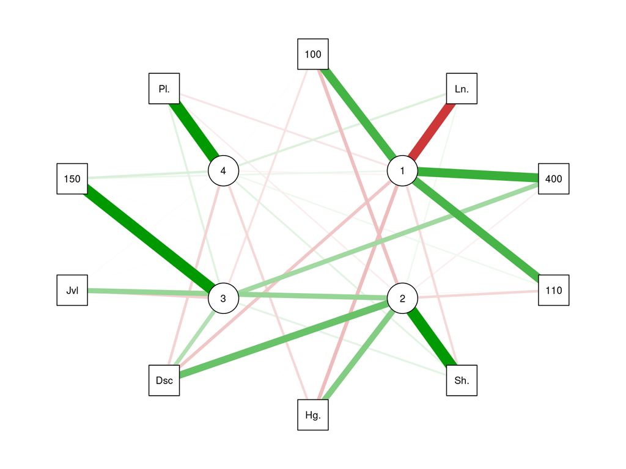

#Escore de Fatores

- Em muitas aplicações, o pesquisador deseja apenas verificar se um modelo de análise fatorial se encaixa nos dados e identificar os fatores. Em outras aplicações, o pesquisador deseja obter escores dos fatores.
- Existem dois usos possíveis para essas pontuações:
1. o comportamento das observações em termos dos fatores pode ser interessante
2. podemos desejar usar as pontuações fatoriais como entrada para outra análise

O último uso se assemelha a uma aplicação semelhante dos componentes principais. Fazemos aqui uma analogia **GROSSEIRA**.

Comparamos escore de fatores $\mathbf{f}_i$ com os componentes da ACP e loadings com os autovetores da ACP

#Escore de Fatores

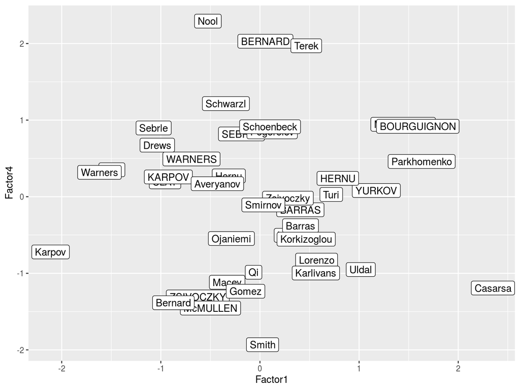

#Interpretação Subjetiva dos Escores de Fatores

```
##          100m Long.jump Shot.put High.jump  400m 110m.hurdle Discus Pole.vault
## BERNARD 11.02      7.23    14.25      1.92 48.93       14.99  40.87       5.32
## Karpov  10.50      7.81    15.93      2.09 46.81       13.97  51.65       4.60
## Nool    10.80      7.53    14.26      1.88 48.81       14.80  42.05       5.40
## Smith   10.85      6.81    15.24      1.91 49.27       14.01  49.02       4.20
## Terek   10.92      6.94    15.15      1.94 49.56       15.12  45.62       5.30
## Casarsa 11.36      6.68    14.92      1.94 53.20       15.39  48.66       4.40
##         Javeline  1500m Rank Points Competition
## BERNARD    62.77 280.10    4   8067    Decastar
## Karpov     55.54 278.11    3   8725    OlympicG
## Nool       61.33 276.33    8   8235    OlympicG
## Smith      61.52 272.74   14   8023    OlympicG
## Terek      50.62 290.36   21   7893    OlympicG
## Casarsa    58.62 296.12   28   7404    OlympicG
```

#Interpretação Subjetiva dos Escores de Fatores

- Considerando que o primeiro fator seja corridas de curta a média distâncias e salto em distâncias.
- Considerando ainda quem vence as corridas quem faz em menor tempo e quem ganha o salto é quem salta em maior distância.
- Podemos ver que quanto mais negativo o valor do escore do fator 1, o atleta saltou mais longe e correu as corridas de 100 e 400 m em menor tempo. Por outro lado, quanto maior valor do escore, o atleta correu em mais tempo e saltou mais curto.
- Considerando que o quarto fator represente eficiência no salto com varas.